# FINAL REPORT DRD MODULE 2- Beatrice Pastorino

## step 4.Create the object MSet.raw

```r
if (!require("BiocManager", quietly = TRUE))
  install.packages("BiocManager")
BiocManager::install("IlluminaHumanMethylation450kmanifest")
```

```r
MSet.raw <- preprocessRaw(RGset)
save(MSet.raw,file="MSet_raw.RData")
```

```r
Meth <- getMeth(MSet.raw)
str(Meth)
head(Meth)
Unmeth <- getUnmeth(MSet.raw)
str(Unmeth)
head(Unmeth)
Unmeth[rownames(Unmeth)=="cg01707559",]
Meth[rownames(Meth)=="cg01707559",]
```

```
 int [1:485512, 1:8] 10599 159 571 200 3331 805 241 15833 7062 2532 ...
 - attr(*, "dimnames")=List of 2
  ..$ : chr [1:485512] "cg00050873" "cg00212031" "cg00213748" "cg00214611" ...
  ..$ : chr [1:8] "200400320115_R01C01" "200400320115_R02C01" "200400320115_R03C01" "200400320115_R04C01" ...
```

A matrix: 6 × 8 of type int

|  | 200400320115_R01C01 | 200400320115_R02C01 | 200400320115_R03C01 | 200400320115_R04C01 | 200400320115_R02C02 | 200400320115_R03C02 | 200400320115_R04C02 | 200400320115_R05C02 |
| --- | --- | --- | --- | --- | --- | --- | --- | --- |
| cg00050873 | 10599 | 10685 | 11049 | 10913 | 1860 | 1334 | 8060 | 294 |
| cg00212031 | 159 | 45 | 211 | 126 | 243 | 179 | 159 | 311 |
| cg00213748 | 571 | 797 | 452 | 520 | 188 | 371 | 256 | 353 |
| cg00214611 | 200 | 223 | 261 | 309 | 87 | 336 | 200 | 300 |
| cg00455876 | 3331 | 3337 | 2147 | 3048 | 424 | 355 | 2076 | 272 |
| cg01707559 | 805 | 713 | 937 | 1123 | 512 | 638 | 563 | 516 |

```
 int [1:485512, 1:8] 7045 7051 1566 5400 2718 9754 7375 4182 1917 5950 ...
 - attr(*, "dimnames")=List of 2
  ..$ : chr [1:485512] "cg00050873" "cg00212031" "cg00213748" "cg00214611" ...
  ..$ : chr [1:8] "200400320115_R01C01" "200400320115_R02C01" "200400320115_R03C01" "200400320115_R04C01" ...
```

A matrix: 6 × 8 of type int

|  | 200400320115_R01C01 | 200400320115_R02C01 | 200400320115_R03C01 | 200400320115_R04C01 | 200400320115_R02C02 | 200400320115_R03C02 | 200400320115_R04C02 | 200400320115_R05C02 |
| --- | --- | --- | --- | --- | --- | --- | --- | --- |
| cg00050873 | 7045 | 9052 | 7985 | 8208 | 816 | 893 | 10036 | 354 |
| cg00212031 | 7051 | 7605 | 6994 | 6964 | 402 | 386 | 4136 | 227 |
| cg00213748 | 1566 | 1687 | 2131 | 2175 | 316 | 370 | 1716 | 312 |
| cg00214611 | 5400 | 5903 | 5505 | 5667 | 290 | 383 | 3288 | 369 |
| cg00455876 | 2718 | 2635 | 2593 | 2748 | 1006 | 1055 | 2566 | 707 |
| cg01707559 | 9754 | 10517 | 9276 | 10325 | 2639 | 2550 | 6758 | 2536 |

**200400320115_R01C01**

9754

**200400320115_R02C01**

10517

**200400320115_R03C01**

9276

**200400320115_R04C01**

10325

**200400320115_R02C02**

2639

**200400320115_R03C02**

2550

**200400320115_R04C02**

6758

**200400320115_R05C02**

2536

**200400320115_R01C01**

805

**200400320115_R02C01**

713

**200400320115_R03C01**

937

**200400320115_R04C01**

1123

**200400320115_R02C02**

512

**200400320115_R03C02**

638

**200400320115_R04C02**

563

**200400320115_R05C02**

516

# step 5. Perform the following quality checks and provide a brief comment to each step:

### 5.1 QCplot

```
DataFrame with 8 rows and 2 columns
                         mMed      uMed
                    <numeric> <numeric>
200400320115_R01C01   11.4236   12.1049
200400320115_R02C01   11.6221   12.2085
200400320115_R03C01   11.6931   12.1341
200400320115_R04C01   11.5372   12.0941
200400320115_R02C02   11.2076   12.1920
200400320115_R03C02   11.3750   12.2935
200400320115_R04C02   11.6348   12.1170
200400320115_R05C02   11.2015   12.0536
```

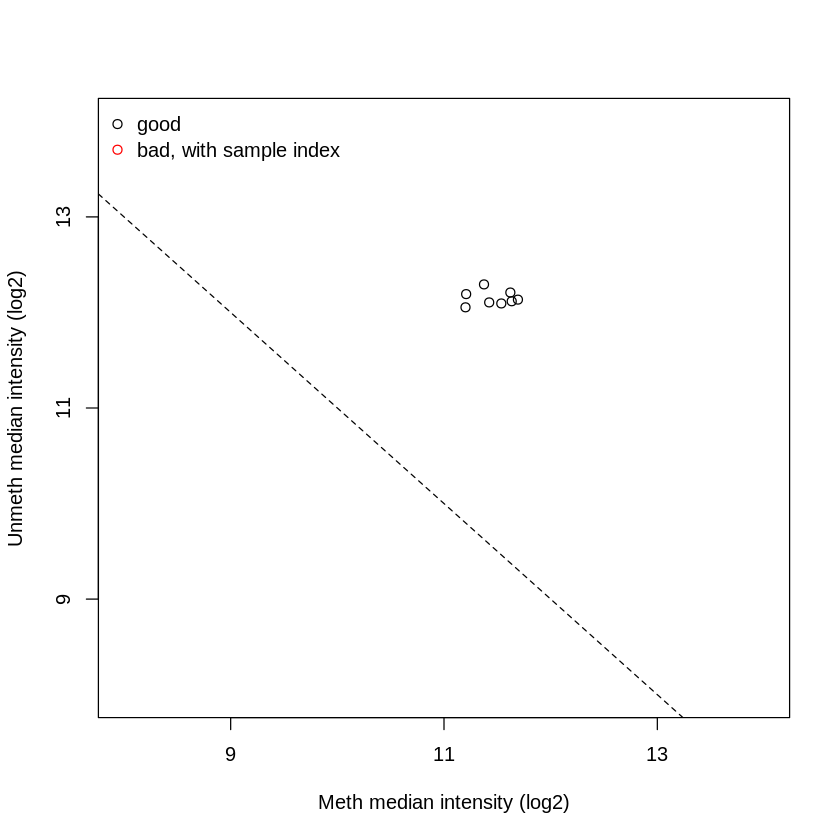

```r
# First of all, considering the median of methylation and unmethylation channels for each sample, using the function getQC
qc <- getQC(MSet.raw)
qc
plotQC(qc)
# All the samples have high median methylation and unmethylation signals, they have good quality
```

### 5.2 control probes

```r
# Then,checking the control probes. The Illumina guide (GenomeStudio_control_probes.pdf) tells us the expected intensities for each type of control probes.

# To know the names and the numbers of the different types of control probes, apply the getProbeInfo function to the RGset object.
getProbeInfo(RGset, type = "Control")
df_TypeControl <- data.frame(getProbeInfo(RGset, type = "Control"))
str(df_TypeControl)
table(df_TypeControl$Type)
```

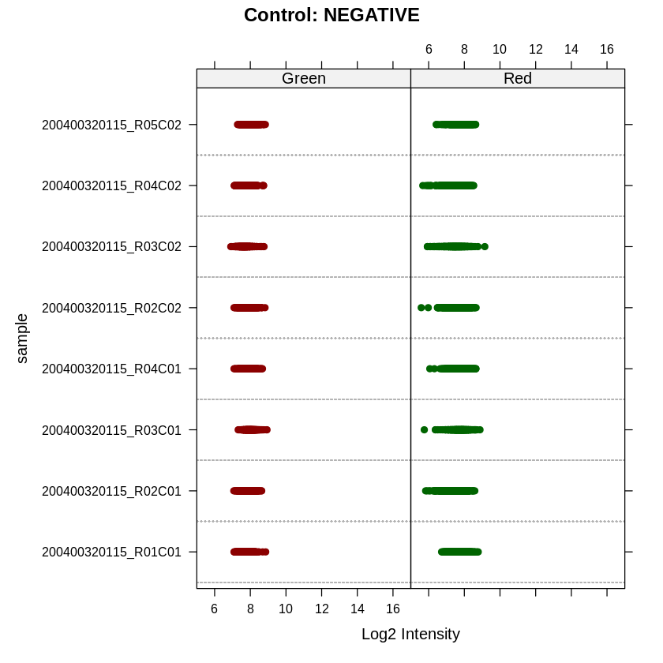

```r
# checking the intensity of negative controls using minfi
controlStripPlot(RGset, controls="NEGATIVE")
# Negative controls are all fine, as all below 1000 (log2(1000)=10) they should be below 10 in this graph
# Green and red labels are swapped because of the version of R
```

## 5.3 calculate detection p-values; for each sample, how many probes have a detection p-value higher than the threshold assigned to me(0.01)?

```r
# using The detectionP() functions.
detP <- detectionP(RGset)
save(detP,file="detP.RData")
load("detP.RData")
str(detP)
dim(detP)
head(detP)
# In the detP object rownames are the CpG probes names
```

```
 num [1:485512, 1:8] 0.00 0.00 1.23e-65 0.00 0.00 ...
 - attr(*, "dimnames")=List of 2
  ..$ : chr [1:485512] "cg00050873" "cg00212031" "cg00213748" "cg00214611" ...
  ..$ : chr [1:8] "200400320115_R01C01" "200400320115_R02C01" "200400320115_R03C01" "200400320115_R04C01" ...
```

1. 485512

2. 8

A matrix: 6 × 8 of type dbl

|  | 200400320115_R01C01 | 200400320115_R02C01 | 200400320115_R03C01 | 200400320115_R04C01 | 200400320115_R02C02 | 200400320115_R03C02 | 200400320115_R04C02 | 200400320115_R05C02 |
| --- | --- | --- | --- | --- | --- | --- | --- | --- |
| cg00050873 | 0.000000e+00 | 0.000000e+00 | 0.000000e+00 | 0.000000e+00 | 5.480893e-129 | 2.198018e-76 | 0.000000e+00 | 1.752486e-02 |
| cg00212031 | 0.000000e+00 | 0.000000e+00 | 0.000000e+00 | 0.000000e+00 | 3.170755e-03 | 2.419784e-02 | 0.000000e+00 | 1.714368e-01 |
| cg00213748 | 1.228993e-65 | 1.729992e-111 | 5.232839e-107 | 1.126935e-126 | 1.068248e-01 | 9.976210e-05 | 3.701058e-68 | 1.109951e-02 |
| cg00214611 | 0.000000e+00 | 0.000000e+00 | 0.000000e+00 | 0.000000e+00 | 5.377831e-01 | 2.314098e-04 | 3.492851e-252 | 9.926860e-03 |
| cg00455876 | 0.000000e+00 | 0.000000e+00 | 0.000000e+00 | 0.000000e+00 | 1.855722e-28 | 1.977299e-25 | 0.000000e+00 | 1.095722e-08 |
| cg01707559 | 0.000000e+00 | 0.000000e+00 | 0.000000e+00 | 0.000000e+00 | 5.574595e-187 | 1.034822e-172 | 0.000000e+00 | 4.171220e-166 |

```r
# Now considering a detectionP threshold of 0.01
failed <- detP>0.01
head(failed)
dim(failed)
table(failed)
```

A matrix: 6 × 8 of type lgl

|  | 200400320115_R01C01 | 200400320115_R02C01 | 200400320115_R03C01 | 200400320115_R04C01 | 200400320115_R02C02 | 200400320115_R03C02 | 200400320115_R04C02 | 200400320115_R05C02 |
| --- | --- | --- | --- | --- | --- | --- | --- | --- |
| cg00050873 | FALSE | FALSE | FALSE | FALSE | FALSE | FALSE | FALSE | TRUE |
| cg00212031 | FALSE | FALSE | FALSE | FALSE | FALSE | TRUE | FALSE | TRUE |
| cg00213748 | FALSE | FALSE | FALSE | FALSE | TRUE | FALSE | FALSE | TRUE |
| cg00214611 | FALSE | FALSE | FALSE | FALSE | TRUE | FALSE | FALSE | FALSE |
| cg00455876 | FALSE | FALSE | FALSE | FALSE | FALSE | FALSE | FALSE | FALSE |
| cg01707559 | FALSE | FALSE | FALSE | FALSE | FALSE | FALSE | FALSE | FALSE |

1. 485512

2. 8

```
failed
  FALSE    TRUE
3882925    1171
```

```r
# summary(failed) is particularly useful, as it returns the number of failed (TRUE) and not failed (FALSE) positions for each sample
summary(failed)
```

```
 200400320115_R01C01 200400320115_R02C01 200400320115_R03C01
 Mode :logical       Mode :logical       Mode :logical
 FALSE:485456        FALSE:485473        FALSE:485470
 TRUE :56            TRUE :39            TRUE :42
 200400320115_R04C01 200400320115_R02C02 200400320115_R03C02
 Mode :logical       Mode :logical       Mode :logical
 FALSE:485477        FALSE:485270        FALSE:485326
 TRUE :35            TRUE :242           TRUE :186
 200400320115_R04C02 200400320115_R05C02
 Mode :logical       Mode :logical
 FALSE:485491        FALSE:484962
 TRUE :21            TRUE :550
```

```r
# creating the table
table_failed <- data.frame(
  failed_positions = colSums(failed == TRUE)
)
table_failed
```

A data.frame: 8 × 1

|  | failed_positions <dbl> |
| --- | --- |
| 200400320115_R01C01 | 56 |
| 200400320115_R02C01 | 39 |
| 200400320115_R03C01 | 42 |
| 200400320115_R04C01 | 35 |
| 200400320115_R02C02 | 242 |
| 200400320115_R03C02 | 186 |
| 200400320115_R04C02 | 21 |
| 200400320115_R05C02 | 550 |

## 6. Calculate raw beta and M values and plot the densities of mean methylation values, dividing the samples in WT and MUT (suggestion: subset the beta and M values matrixes in order to retain WT or MUT subjects and apply the function mean to the 2 subsets). Do you see any difference between the two groups?

```r
# Beta and M values
# The functions getBeta and getM allow to retrieve beta and M values matrices:
beta <- getBeta(MSet.raw)
class(beta)
dim(beta)
head(beta)
summary(beta)
# In this dataset, minimum for beta values is 0 maximum is 1 We have also some NAs: these are the positions for which both the Methylation and Unmethylation values in the MSet.raw are equal to 0 (by default, in minfi the offset is set to 0)
```

1. 'matrix'

2. 'array'

1. 485512

2. 8

A matrix: 6 × 8 of type dbl

|  | 200400320115_R01C01 | 200400320115_R02C01 | 200400320115_R03C01 | 200400320115_R04C01 | 200400320115_R02C02 | 200400320115_R03C02 | 200400320115_R04C02 | 200400320115_R05C02 |
| --- | --- | --- | --- | --- | --- | --- | --- | --- |
| cg00050873 | 0.60071412 | 0.541369002 | 0.58048755 | 0.57073375 | 0.6950673 | 0.5990121 | 0.44540230 | 0.4537037 |
| cg00212031 | 0.02205270 | 0.005882353 | 0.02928522 | 0.01777151 | 0.3767442 | 0.3168142 | 0.03701979 | 0.5780669 |
| cg00213748 | 0.26719701 | 0.320853462 | 0.17499032 | 0.19294991 | 0.3730159 | 0.5006748 | 0.12981744 | 0.5308271 |
| cg00214611 | 0.03571429 | 0.036402220 | 0.04526535 | 0.05170683 | 0.2307692 | 0.4673157 | 0.05733945 | 0.4484305 |
| cg00455876 | 0.55066953 | 0.558774280 | 0.45295359 | 0.52587992 | 0.2965035 | 0.2517730 | 0.44722103 | 0.2778345 |
| cg01707559 | 0.07623828 | 0.063490650 | 0.09174581 | 0.09809574 | 0.1624881 | 0.2001255 | 0.07690206 | 0.1690695 |

```
 200400320115_R01C01 200400320115_R02C01 200400320115_R03C01
 Min.   :0.00000     Min.   :0.0000      Min.   :0.0000
 1st Qu.:0.09362     1st Qu.:0.1050      1st Qu.:0.1058
 Median :0.44480     Median :0.4672      Median :0.4826
 Mean   :0.44829     Mean   :0.4562      Mean   :0.4682
 3rd Qu.:0.79004     3rd Qu.:0.7869      3rd Qu.:0.8150
 Max.   :1.00000     Max.   :1.0000      Max.   :1.0000
 NA's   :19          NA's   :12          NA's   :12
 200400320115_R04C01 200400320115_R02C02 200400320115_R03C02
 Min.   :0.0000      Min.   :0.0000      Min.   :0.0000
 1st Qu.:0.1063      1st Qu.:0.1065      1st Qu.:0.1069
 Median :0.4734      Median :0.3706      Median :0.3970
 Mean   :0.4625      Mean   :0.4286      Mean   :0.4350
 3rd Qu.:0.8041      3rd Qu.:0.7609      3rd Qu.:0.7691
 Max.   :1.0000      Max.   :1.0000      Max.   :1.0000
 NA's   :14          NA's   :30          NA's   :21
 200400320115_R04C02 200400320115_R05C02
 Min.   :0.0000      Min.   :0.0000
 1st Qu.:0.1110      1st Qu.:0.1155
 Median :0.4767      Median :0.4421
 Mean   :0.4641      Mean   :0.4523
 3rd Qu.:0.7989      3rd Qu.:0.7804
 Max.   :1.0000      Max.   :1.0000
 NA's   :10          NA's   :17
```

```r
# Computing M values,M values are more statistical reliable than beta values (std of m values is not effected by mean of m values)
M <- getM(MSet.raw)
dim(M)
head(M)
summary(M)
# In this dataset, minimum for M values is -Inf (Methylation value=0, Unmethylation value>0), maximum is +Inf (Methylation value>0, Unmethylation value=0). I have also some NAs: these are the positions for which both the Methylation and Unmethylation values in the MSet.raw are equal to 0 (by default, in minfi the offset is set to 0)
```

1. 485512

2. 8

A matrix: 6 × 8 of type dbl

|  | 200400320115_R01C01 | 200400320115_R02C01 | 200400320115_R03C01 | 200400320115_R04C01 | 200400320115_R02C02 | 200400320115_R03C02 | 200400320115_R04C02 | 200400320115_R05C02 |
| --- | --- | --- | --- | --- | --- | --- | --- | --- |
| cg00050873 | 0.5892565 | 0.2392784 | 0.4685515 | 0.4109451 | 1.1886616 | 0.579026586 | -0.3163326 | -0.2679332 |
| cg00212031 | -5.4707292 | -7.4008794 | -5.0508029 | -5.7884206 | -0.7262392 | -1.108641260 | -4.7011375 | 0.4542223 |
| cg00213748 | -1.4555216 | -1.0818083 | -2.2371359 | -2.0644319 | -0.7491919 | 0.003893916 | -2.7448338 | 0.1781222 |
| cg00214611 | -4.7548875 | -4.7263327 | -4.3986209 | -4.1969065 | -1.7369656 | -0.188883159 | -4.0391384 | -0.2986583 |
| cg00455876 | 0.2934099 | 0.3407487 | -0.2723000 | 0.1494809 | -1.2464941 | -1.571352069 | -0.3057147 | -1.3781036 |
| cg01707559 | -3.5989333 | -3.8826773 | -3.3073819 | -3.2007119 | -2.3657756 | -1.998868918 | -3.5853895 | -2.2971118 |

```
 200400320115_R01C01 200400320115_R02C01 200400320115_R03C01
 Min.   :   -Inf     Min.   :   -Inf     Min.   :   -Inf
 1st Qu.:-3.2752     1st Qu.:-3.0910     1st Qu.:-3.0788
 Median :-0.3198     Median :-0.1897     Median :-0.1003
 Mean   :    NaN     Mean   :    NaN     Mean   :    NaN
 3rd Qu.: 1.9118     3rd Qu.: 1.8850     3rd Qu.: 2.1396
 Max.   :    Inf     Max.   :    Inf     Max.   :    Inf
 NA's   :19          NA's   :12          NA's   :12
 200400320115_R04C01 200400320115_R02C02 200400320115_R03C02
 Min.   :   -Inf     Min.   :   -Inf     Min.   :   -Inf
 1st Qu.:-3.0720     1st Qu.:-3.0686     1st Qu.:-3.0625
 Median :-0.1538     Median :-0.7641     Median :-0.6028
 Mean   :    NaN     Mean   :    NaN     Mean   :    NaN
 3rd Qu.: 2.0372     3rd Qu.: 1.6700     3rd Qu.: 1.7357
 Max.   :    Inf     Max.   :    Inf     Max.   :    Inf
 NA's   :14          NA's   :30          NA's   :21
 200400320115_R04C02 200400320115_R05C02
 Min.   :   -Inf     Min.   :   -Inf
 1st Qu.:-3.0017     1st Qu.:-2.9370
 Median :-0.1346     Median :-0.3359
 Mean   :    NaN     Mean   :    NaN
 3rd Qu.: 1.9897     3rd Qu.: 1.8297
 Max.   :    Inf     Max.   :    Inf
 NA's   :10          NA's   :17
```

```r
# Subsetting the RGset based on the wt and mut groups:
wt <- RGset@colData[RGset@colData$Group == "WT",]
mut <- RGset@colData[RGset@colData$Group == "MUT",]
wt
mut
```

```
DataFrame with 4 rows and 8 columns
                         Sample       Group         Sex       Age       Array
                    <character> <character> <character> <integer> <character>
200400320115_R01C01           A          WT           M         1      R01C01
200400320115_R03C01           C          WT           M         5      R03C01
200400320115_R04C01           D          WT           M         0      R04C01
200400320115_R04C02           G          WT           F         9      R04C02
                           Slide               Basename              filenames
                     <character>            <character>            <character>
200400320115_R01C01 200400320115 /media/200400320115_.. /media/200400320115_..
200400320115_R03C01 200400320115 /media/200400320115_.. /media/200400320115_..
200400320115_R04C01 200400320115 /media/200400320115_.. /media/200400320115_..
200400320115_R04C02 200400320115 /media/200400320115_.. /media/200400320115_..
```

```
DataFrame with 4 rows and 8 columns
                         Sample       Group         Sex       Age       Array
                    <character> <character> <character> <integer> <character>
200400320115_R02C01           B         MUT           F         1      R02C01
200400320115_R02C02           E         MUT           F         3      R02C02
200400320115_R03C02           F         MUT           F         2      R03C02
200400320115_R05C02           H         MUT           F         1      R05C02
                           Slide               Basename              filenames
                     <character>            <character>            <character>
200400320115_R02C01 200400320115 /media/200400320115_.. /media/200400320115_..
200400320115_R02C02 200400320115 /media/200400320115_.. /media/200400320115_..
200400320115_R03C02 200400320115 /media/200400320115_.. /media/200400320115_..
200400320115_R05C02 200400320115 /media/200400320115_.. /media/200400320115_..
```

```r
# Storing the names of wt samples
samples_wt <- rownames(wt)
samples_wt
```

1. '200400320115_R01C01'

2. '200400320115_R03C01'

3. '200400320115_R04C01'

4. '200400320115_R04C02'

```r
# Storing the names of mut samples
samples_mut <- rownames(mut)
samples_mut
```

1. '200400320115_R02C01'

2. '200400320115_R02C02'

3. '200400320115_R03C02'

4. '200400320115_R05C02'

```r
# Subsetting the beta values into beta values for wt
beta_wt <- beta[,samples_wt]
```

```r
#subsetting the beta values into beta values for mut
beta_mut <- beta[,samples_mut]
```

```r
# Calculating mean of beta values for wt samples and mean of beta values for mut samples
# To calculate the mean, we will use the mean() function. As we know that in our input there are some missing values, we will specify that NA values should be stripped (see this page https://www.statmethods.net/input/missingdata.html) using the na.rm=T argument.
# To calculate the mean of each row of the matrix, we will use the apply() function, which takes as input a dataframe or a matrix and returns a vector (see here for example: http://petewerner.blogspot.it/2012/12/using-apply-sapply-lapply-in-r.html). Note that the "MARGIN" argument in the function allows to specify that the function mean() should be applied to each row (set "MARGIN" to 1) or to each column (set "MARGIN" to 2) of the matrix/dataframe.
mean_of_beta_mut <-apply(beta_mut,1,mean,na.rm=T)
mean_of_beta_wt <-apply(beta_wt,1,mean,na.rm=T)
```

```r
# Now I can calculate the density distribution
# removing missing values from the vector because density function doesn't accept those
mean_of_beta_wt <- mean_of_beta_wt[!is.na(mean_of_beta_wt)]
d_mean_of_beta_wt <- density(mean_of_beta_wt)
mean_of_beta_mut <- mean_of_beta_mut[!is.na(mean_of_beta_mut)]
d_mean_of_beta_mut <- density(mean_of_beta_mut)
```

[figure not shown]

```r
# plotting the beta values in orange for the wt samples and in red for mut samples
plot(d_mean_of_beta_wt, main="Density of Beta Values",col="orange")
lines(d_mean_of_beta_mut,col="red")
# the Beta values appear to be highly bimodal, because are compressed in the low (between 0 and 0.2) and high (between 0.8 and 1) methylation ranges. In other words, I have 2 peaks, one for low methylation values, near 0, and another peak for high methylation values
```

```r
# subsetting the m values into m values for wt and m values for mut
M_wt <- M[,samples_wt]
M_mut <- M[,samples_mut]
```

```r
# I apply the same steps on M values to plot M values for MT samples and WT samples:
mean_of_M_wt <- apply(M_wt,1,mean,na.rm=T)
mean_of_M_wt <- mean_of_M_wt[!is.na(mean_of_M_wt)]
mean_of_M_mut <- apply(M_mut,1,mean,na.rm=T)
mean_of_M_mut <- mean_of_M_mut[!is.na(mean_of_M_mut)]
d_mean_of_M_wt <- density(mean_of_M_wt)
d_mean_of_M_mut <- density(mean_of_M_mut)
```

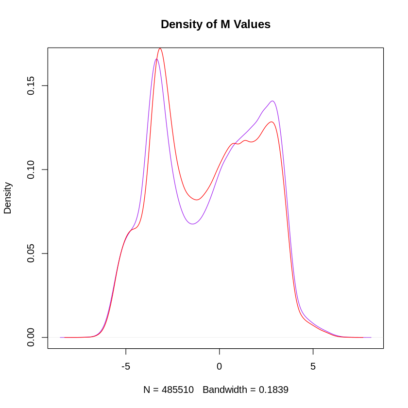

```r
# plotting the M values purple for wt samples and red for mut samples
plot(d_mean_of_M_wt,main="Density of M Values",col="purple")
lines(d_mean_of_M_mut,col="red")
```

[figure not shown]

[figure not shown]

```r
# checking boxplot for beta values
par(mfrow=c(1,2))
boxplot(beta_wt,main="beta values wt", col="purple")
boxplot(beta_mut,main="beta values wt", col="red")
boxplot(beta,main="beta values mut")
```

## Step 7.Normalize the data using the function assigned to each student and compare raw data and normalized data. Produce a plot with 6 panels in which, for both raw and normalized data, you show the density plots of beta mean values according to the chemistry of the probes, the density plot of beta standard deviation values according to the chemistry of the probes and the boxplot of beta values. Provide a short comment about the changes you observe.

```r
# subsetting the Illumina450Manifest_clean in two dataframes, containing only type I (dfI) or type II (dfII) probes
dfI <- Illumina450Manifest_clean[Illumina450Manifest_clean$Infinium_Design_Type=="I",]
dfI <- droplevels(dfI)
dim(dfI)
str(dfI)
dfII <- Illumina450Manifest_clean[Illumina450Manifest_clean$Infinium_Design_Type=="II",]
dfII <- droplevels(dfII)
```

1. 135476

2. 33

```
'data.frame':	135476 obs. of  33 variables:
 $ IlmnID                     : Factor w/ 135476 levels "cg00000622","cg00000769",..: 311 1089 1099 1106 2280 8496 10019 10061 10250 11112 ...
 $ Name                       : Factor w/ 135476 levels "cg00000622","cg00000769",..: 311 1089 1099 1106 2280 8496 10019 10061 10250 11112 ...
 $ AddressA_ID                : Factor w/ 135476 levels "10600328","10600369",..: 47762 40844 43302 125252 36295 74624 33361 35577 70485 133756 ...
 $ AlleleA_ProbeSeq           : Factor w/ 135476 levels "AAAAAAAAAAAAAAAAAACCACAAAAAAATCCCCACTCTAAAACCCCACA",..: 46999 97650 135088 103784 39883 50177 55080 65466 80679 129398 ...
 $ AddressB_ID                : Factor w/ 135476 levels "10600313","10600353",..: 45513 60127 56498 76847 124346 114306 100943 109732 132012 11815 ...
 $ AlleleB_ProbeSeq           : Factor w/ 135476 levels "AAAAAAAAAAAAAAAAAACCGCGAAAAAATCCCCGCTCTAAAACCCCGCG",..: 49666 77343 135091 95677 35570 107971 45139 58259 69459 129398 ...
 $ Infinium_Design_Type       : Factor w/ 1 level "I": 1 1 1 1 1 1 1 1 1 1 ...
 $ Next_Base                  : Factor w/ 3 levels "A","C","T": 1 3 1 1 1 1 2 1 2 2 ...
 $ Color_Channel              : Factor w/ 2 levels "Grn","Red": 2 2 2 2 2 2 1 2 1 1 ...
 $ Forward_Sequence           : Factor w/ 135476 levels "AAAAAAAAAAAAAAAAAAAAAAAAAAAAGCTTGCCCCAACATCGGTATATTCCAAATTCG[CG]CGTGCTTCCGAAGGCTCATATTCTCGGCCCTTTCAGACGCTCTTAAAATTTTTCTCCTAG",..: 113476 36406 121253 84324 53100 15696 80195 14484 40097 106165 ...
 $ Genome_Build               : int  37 37 37 37 37 37 37 37 37 37 ...
 $ CHR                        : Factor w/ 24 levels "1","10","11",..: 24 24 24 24 24 24 24 24 24 24 ...
 $ MAPINFO                    : int  9363356 21239348 8148233 15815688 9385539 6778695 15815552 9194502 22918038 22737591 ...
 $ SourceSeq                  : Factor w/ 135431 levels "AAAAAAAAAATCCCCGTTGCTCTTTACACCCCGGAAACGGCAAGGGAACG",..: 83347 29309 36834 39256 98271 40812 71752 120603 16821 126495 ...
```

[output cut: 19 more lines]

```r
# Now subsetting the beta matrix in order to retain only the rows whose name is in the first column of dfI...
beta_I <- beta[rownames(beta) %in% dfI$IlmnID,]
dim(beta_I)
# ... or in the first column of dfII
beta_II <- beta[rownames(beta) %in% dfII$IlmnID,]
dim(beta_II)
```

1. 135476

2. 8

1. 350036

2. 8

```r
# For each probe in the mean_of_beta_I and mean_of_beta_II matrices, calculating the mean of beta values across the 8 samples...
mean_of_beta_I <- apply(beta_I,1,mean)
mean_of_beta_II <- apply(beta_II,1,mean)
```

```r
# ... and then we calculate the density distribution of the 2 vectors of mean values:
d_mean_of_beta_I <- density(mean_of_beta_I,na.rm=T)
d_mean_of_beta_II <- density(mean_of_beta_II,na.rm=T)
```

```r
# For Raw data, I already have the matrix of beta values, the d_mean_of_beta_I and d_mean_of_beta_II objects; I need to calculate the densities of the standard deviations, which can be calculated using the function sd():
sd_of_beta_I <- apply(beta_I,1,sd,na.rm=T)
sd_of_beta_II <- apply(beta_II,1,sd,na.rm=T)
d_sd_of_beta_I <- density(sd_of_beta_I,)
sd_of_beta_II <- sd_of_beta_II[!is.na(sd_of_beta_II)]
d_sd_of_beta_II <- density(sd_of_beta_II)
```

```r
if (!require("BiocManager", quietly = TRUE))
  install.packages("BiocManager")
BiocManager::install("IlluminaHumanMethylation450kanno.ilmn12.hg19")
```

```r
# normalisation with preprocessfunnnorm
# This function implements functional normalization preprocessing for Illumina methylation microarrays. Functional normalization extends the idea of quantile normalization by adjusting for known covariates measuring unwanted variation.
#preprocessFunnorm_results <- preprocessFunnorm(RGset)

load("/media/preprocessFunnorm_results.R")
```

```r
#I am loading the file of normalisation data from precomputed step (preprocessFunnorm_results <- preprocessFunnorm(RGset)) in Rstudio because here in jupyter the Normalisation function doesn't work
```

```r
# GetBeta is among the accessor functions of a GenomicRatioSet class object
beta_preprocessFunnorm <- getBeta(preprocessFunnorm_results)
```

```r
# Now dividing the beta_preprocessFunnorm matrix according to type I and type II probes, calculate the mean and the standartd deviation for each probe across the 8 samples and calculate the density distributions
beta_preprocessFunnorm_I <- beta_preprocessFunnorm[rownames(beta_preprocessFunnorm) %in% dfI$IlmnID,]
beta_preprocessFunnorm_II <- beta_preprocessFunnorm[rownames(beta_preprocessFunnorm) %in% dfII$IlmnID,]
mean_of_beta_preprocessFunnorm_I <- apply(beta_preprocessFunnorm_I,1,mean)
mean_of_beta_preprocessFunnorm_II <- apply(beta_preprocessFunnorm_II,1,mean)
d_mean_of_beta_preprocessFunnorm_I <- density(mean_of_beta_preprocessFunnorm_I,na.rm=T)
d_mean_of_beta_preprocessFunnorm_II <- density(mean_of_beta_preprocessFunnorm_II,na.rm=T)
sd_of_beta_preprocessFunnorm_I <- apply(beta_preprocessFunnorm_I,1,sd)
sd_of_beta_preprocessFunnorm_II <- apply(beta_preprocessFunnorm_II,1,sd)
d_sd_of_beta_preprocessFunnorm_I <- density(sd_of_beta_preprocessFunnorm_I,na.rm=T)
d_sd_of_beta_preprocessFunnorm_II <- density(sd_of_beta_preprocessFunnorm_II,na.rm=T)
```

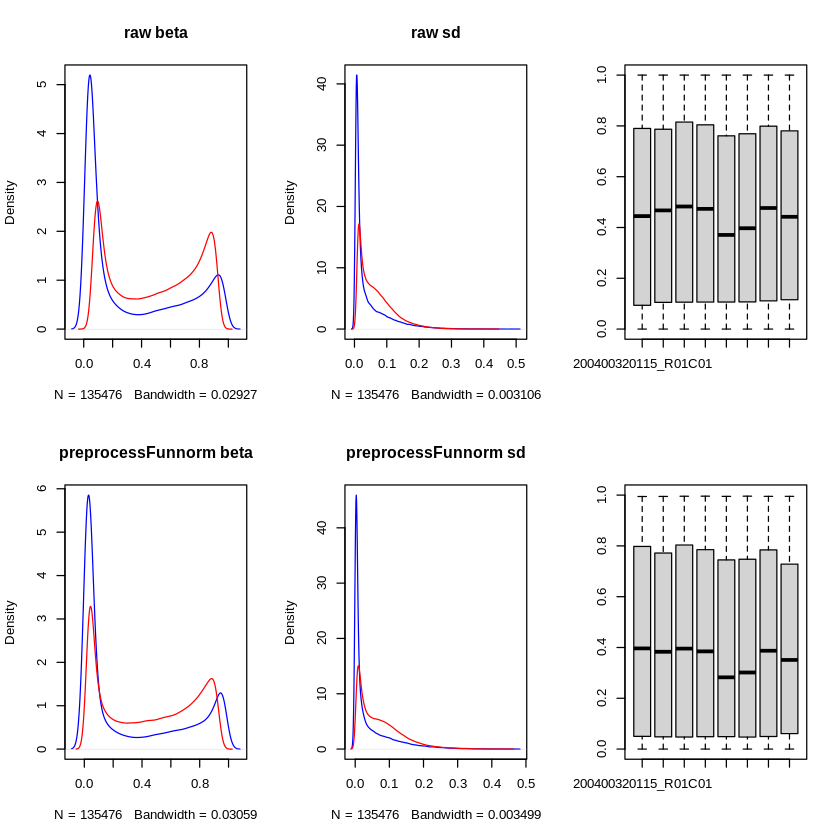

```r
# plotting all of them in the same page with par function
par(mfrow=c(2,3))
plot(d_mean_of_beta_I,col="blue",main="raw beta")
lines(d_mean_of_beta_II,col="red")
plot(d_sd_of_beta_I,col="blue",main="raw sd")
lines(d_sd_of_beta_II,col="red")
boxplot(beta,ylim=c(0,1))
plot(d_mean_of_beta_preprocessFunnorm_I,col="blue",main="preprocessFunnorm beta")
lines(d_mean_of_beta_preprocessFunnorm_II,col="red")
plot(d_sd_of_beta_preprocessFunnorm_I,col="blue",main="preprocessFunnorm sd")
lines(d_sd_of_beta_preprocessFunnorm_II,col="red")
boxplot(beta_preprocessFunnorm,ylim=c(0,1))
```

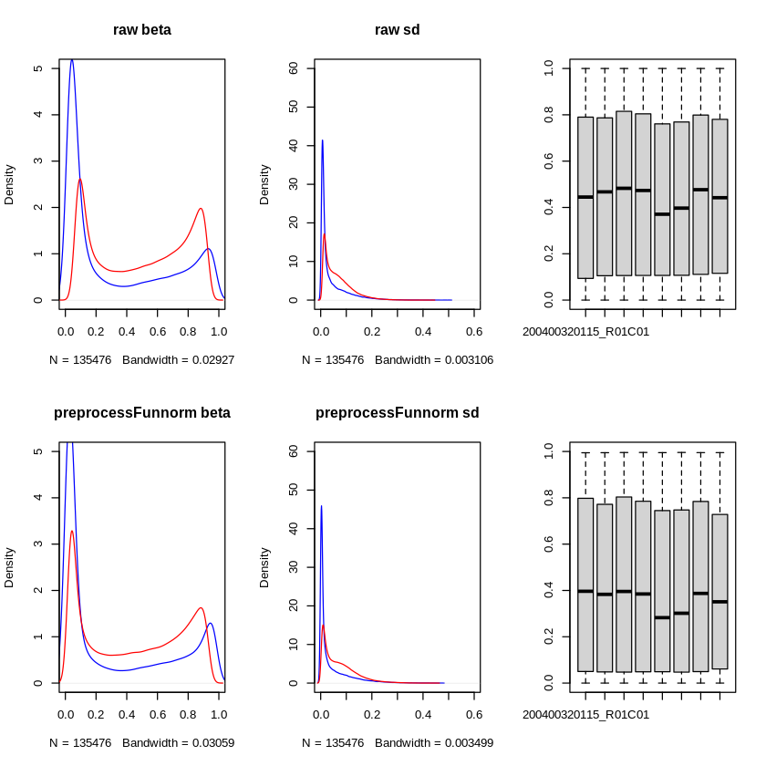

```r
# It is easier to compare the plots if I have the same scales on x and y axes; to this aim, I can specify the xlim and ylim arguments:
par(mfrow=c(2,3))
plot(d_mean_of_beta_I,col="blue",main="raw beta",xlim=c(0,1),ylim=c(0,5))
lines(d_mean_of_beta_II,col="red")
plot(d_sd_of_beta_I,col="blue",main="raw sd",xlim=c(0,0.6),ylim=c(0,60))
lines(d_sd_of_beta_II,col="red")
boxplot(beta,ylim=c(0,1))
plot(d_mean_of_beta_preprocessFunnorm_I,col="blue",main="preprocessFunnorm beta",xlim=c(0,1),ylim=c(0,5))
lines(d_mean_of_beta_preprocessFunnorm_II,col="red")
plot(d_sd_of_beta_preprocessFunnorm_I,col="blue",main="preprocessFunnorm sd",xlim=c(0,0.6),ylim=c(0,60))
lines(d_sd_of_beta_preprocessFunnorm_II,col="red")
boxplot(beta_preprocessFunnorm,ylim=c(0,1))
```

```r
# saving the plots in a pdf file
pdf("Plot_comparison_raw_preprocessFunnorm.pdf",height=7,width=15)
par(mfrow=c(2,3))
plot(d_mean_of_beta_I,col="blue",main="raw beta",xlim=c(0,1),ylim=c(0,5))
lines(d_mean_of_beta_II,col="red")
plot(d_sd_of_beta_I,col="blue",main="raw sd",xlim=c(0,0.6),ylim=c(0,60))
lines(d_sd_of_beta_II,col="red")
boxplot(beta,ylim=c(0,1))
plot(d_mean_of_beta_preprocessFunnorm_I,col="blue",main="preprocessFunnorm beta",xlim=c(0,1),ylim=c(0,5))
lines(d_mean_of_beta_preprocessFunnorm_II,col="red")
plot(d_sd_of_beta_preprocessFunnorm_I,col="blue",main="preprocessFunnorm sd",xlim=c(0,0.6),ylim=c(0,60))
lines(d_sd_of_beta_preprocessFunnorm_II,col="red")
boxplot(beta_preprocessFunnorm,ylim=c(0,1))
dev.off()
```

**png:** 2

## Step 8. Perform a PCA on the matrix of normalized beta values generated in step 7, after normalization. Comment the plot (do the samples divide according to the group? Do they divide according to the sex of the samples? Do they divide according to the batch, that is the column Sentrix_ID?).

```r
# using the function prcomp() to calculate the PCA on my matrix of beta values.
# The matrix has samples in columns and CpG probes in rows: the prcomp() function should be applied to the transposed matrix, which is achieved using the t() function

pca_results <- prcomp(t(beta_preprocessFunnorm),scale=T)
```

```
Importance of components:
                            PC1      PC2      PC3      PC4       PC5       PC6
Standard deviation     402.4126 335.1943 274.6054 226.2413 194.67790 160.09571
Proportion of Variance   0.3335   0.2314   0.1553   0.1054   0.07806   0.05279
Cumulative Proportion    0.3335   0.5649   0.7203   0.8257   0.90375   0.95655
                             PC7       PC8
Standard deviation     145.24982 3.189e-12
Proportion of Variance   0.04345 0.000e+00
Cumulative Proportion    1.00000 1.000e+00
List of 5
 $ sdev    : num [1:8] 402 335 275 226 195 ...
 $ rotation: num [1:485512, 1:8] -0.002411 -0.001317 0.001046 -0.000621 0.001655 ...
  ..- attr(*, "dimnames")=List of 2
  .. ..$ : chr [1:485512] "cg13869341" "cg14008030" "cg12045430" "cg20826792" ...
  .. ..$ : chr [1:8] "PC1" "PC2" "PC3" "PC4" ...
 $ center  : Named num [1:485512] 0.8422 0.6003 0.0425 0.127 0.0361 ...
  ..- attr(*, "names")= chr [1:485512] "cg13869341" "cg14008030" "cg12045430" "cg20826792" ...
 $ scale   : Named num [1:485512] 0.04754 0.08699 0.00482 0.02698 0.00586 ...
  ..- attr(*, "names")= chr [1:485512] "cg13869341" "cg14008030" "cg12045430" "cg20826792" ...
 $ x       : num [1:8, 1:8] -409 -104 -442 -358 452 ...
  ..- attr(*, "dimnames")=List of 2
  .. ..$ : chr [1:8] "200400320115_R01C01" "200400320115_R02C01" "200400320115_R03C01" "200400320115_R04C01" ...
  .. ..$ : chr [1:8] "PC1" "PC2" "PC3" "PC4" ...
 - attr(*, "class")= chr "prcomp"
```

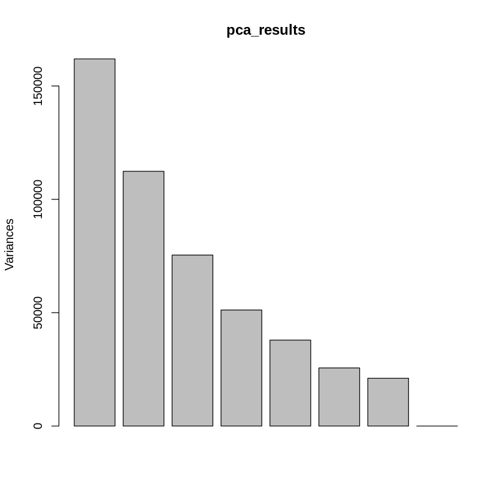

```r
# I can print and plot the variance accounted for each component
print(summary(pca_results))
plot(pca_results)
# Asking the str() of pca_object
str(pca_results)
```

```r
# The principal components of interest are stored in the element named "x" of the list.
pca_results$x
```

A matrix: 8 × 8 of type dbl

|  | PC1 | PC2 | PC3 | PC4 | PC5 | PC6 | PC7 | PC8 |
| --- | --- | --- | --- | --- | --- | --- | --- | --- |
| 200400320115_R01C01 | -408.67362 | 29.830021 | -177.2283 | 27.08522 | -33.411646 | -159.001625 | 277.081787 | 3.539143e-12 |
| 200400320115_R02C01 | -103.62296 | 34.599074 | 349.2493 | -471.82402 | -47.581586 | 23.358076 | 2.113366 | 2.163850e-12 |
| 200400320115_R03C01 | -441.72111 | -4.997495 | -158.9411 | 31.63618 | -44.429873 | -172.854431 | -265.751029 | 3.226520e-12 |
| 200400320115_R04C01 | -358.07737 | 59.524767 | -201.5262 | 43.61582 | 78.004182 | 341.967728 | -7.690468 | 3.544961e-12 |
| 200400320115_R02C02 | 451.76158 | -446.904988 | -142.0805 | 25.62592 | -321.156654 | 46.569641 | 3.200808 | 6.403780e-12 |
| 200400320115_R03C02 | 366.84868 | -350.696146 | -65.5461 | -34.15458 | 387.924383 | -61.715599 | -2.507318 | 2.020546e-12 |
| 200400320115_R04C02 | -46.54265 | 1.801832 | 518.7208 | 360.42845 | -5.023261 | 8.463817 | 6.361000 | -1.353460e-12 |
| 200400320115_R05C02 | 540.02744 | 676.842935 | -122.6479 | 17.58701 | -14.325545 | -26.787607 | -12.808146 | -1.557512e-11 |

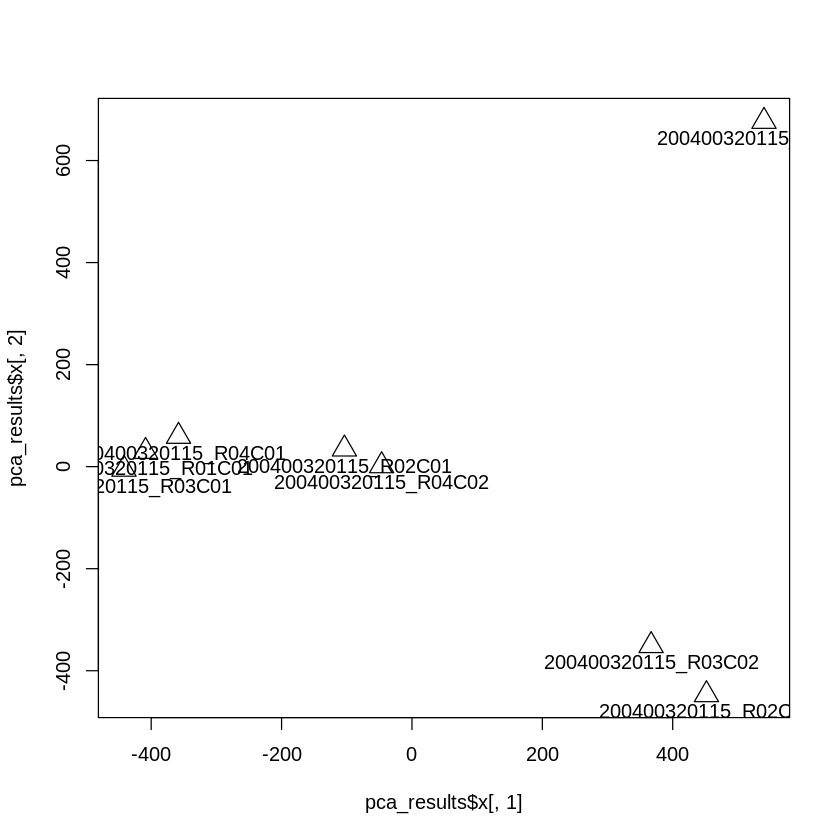

```r
# Plotting PC1 and PC2 and check if samples cluster according to some variable; the argument "cex" defines the size of the dots, the argument "pch" the dot type:
plot(pca_results$x[,1], pca_results$x[,2],cex=2,pch=2)
# labeling the dots using the text() function and setting the "labels" argument to the rownames of pca_results$x; the argument "pos" defines the position of the text:
text(pca_results$x[,1], pca_results$x[,2],labels=rownames(pca_results$x),pos=1)
```